# 🧮 NumPy Tutorial — Foundations for Data Analysis & ML

# 🔍 Chapter 4: Indexing, Slicing & Filtering

### 🎯 Goal:

Select **exactly the rows, columns, and elements** you need — by position, by condition (boolean masks), or by fancy index lists.

```python
import numpy as np
```

# Indexing & Slicing

```python
a = np.array([1,2,3])
a
```

```
array([1, 2, 3])
```

```python
a[2]            # Select the element at the 2nd index
```

```
np.int64(3)
```

```python
a[0:2]          # Select items at index 0 and 1
```

```
array([1, 2])
```

```python
a[::-1]         # Reversed Array
```

```
array([3, 2, 1])
```

```python
b = np.array([(1.5,2,3), (4,5,6)], dtype = float)
b
```

```
array([[1.5, 2. , 3. ],
       [4. , 5. , 6. ]])
```

```python
b[1,2]          # Select the element at row 1 column 2 (equivalent to b[1][2])
```

```
np.float64(6.0)
```

```python
b[:2, 1]        # Select items at rows 0 and 1 in column 1
```

```
array([2., 5.])
```

```python
b[:1]           # Select all items at row 0 (equivalent to b[0:1,:])
```

```
array([[1.5, 2. , 3. ]])
```

```python
c = np.array([[(1.5,2,3), (4,5,6)],[(3,2,1), (4,5,6)]])
c
```

```
array([[[1.5, 2. , 3. ],
        [4. , 5. , 6. ]],

       [[3. , 2. , 1. ],
        [4. , 5. , 6. ]]])
```

```python
c[1, ...]           # Same as [1,:,:]
```

```
array([[3., 2., 1.],
       [4., 5., 6.]])
```

# Boolean Indexing (with Condition)

```python
a
```

```
array([1, 2, 3])
```

```python
a<2
```

```
array([ True, False, False])
```

```python
a[a<2]
```

```
array([1])
```

```python
a[a%2 ==1]
```

```
array([1, 3])
```

```python
b = np.array([3,1,5])
b
```

```
array([3, 1, 5])
```

```python
np.where(a<b)
```

```
(array([0, 2]),)
```

```python
np.intersect1d(a,b)
```

```
array([1, 3])
```

```python
np.union1d(a,b)
```

```
array([1, 2, 3, 5])
```

# Fancy Indexing

```python
C = np.array([[1,2,3],
              [4,5,6],
              [7,8,9],
              [0,0,0]])
```

```python
C[[1,2]]
```

```
array([[4, 5, 6],
       [7, 8, 9]])
```

```python
C[[0,3]]
```

```
array([[1, 2, 3],
       [0, 0, 0]])
```

📌 **Insight:** Boolean masks (`a[a > 2]`) are the NumPy twin of pandas filtering (`df[df["sales"] > 2]`) — learn the pattern here and Chapter 1 of the Pandas Tutorial will feel familiar.

# ➕ Chapter 5: Element-wise Operations

### 🎯 Goal:

Apply arithmetic **element by element** — including the scalar-broadcasting trick (`array + 10`) and fast math functions (`sqrt`/`exp`/`log`).

# Matrix Operations (Element by Element)

```python
import numpy as np
```

### Addition

```python
A = np.array([[10, 20, 30],
              [15, 25, 35]])
A.shape
```

```
(2, 3)
```

```python
B = np.array([[-10, 5, -1],
              [100, 4, 88]])
```

```python
C = A + B
C
```

```
array([[  0,  25,  29],
       [115,  29, 123]])
```

```python
A +=B
A
```

```
array([[  0,  25,  29],
       [115,  29, 123]])
```

```python
A +=B
np.add(A,B,A)
```

```
array([[-20,  35,  27],
       [315,  37, 299]])
```

```python
A
```

```
array([[-20,  35,  27],
       [315,  37, 299]])
```

```python
A[0]
```

```
array([-20,  35,  27])
```

```python
# Adding Vectors
A[0] + B[1]
```

```
array([ 80,  39, 115])
```

```python
# Random Array
E = np.random.rand(3,3)
E
```

```
array([[0.29214465, 0.36636184, 0.45606998],
       [0.78517596, 0.19967378, 0.51423444],
       [0.59241457, 0.04645041, 0.60754485]])
```

```python
#C + E
```

```python
#C[:,0] + E[:,0]
```

```python
C
```

```
array([[  0,  25,  29],
       [115,  29, 123]])
```

```python
# With Scalar
C + 10
```

```
array([[ 10,  35,  39],
       [125,  39, 133]])
```

```python
C + np.array([[10, 10, 10],
             [10, 10, 10]])
```

```
array([[ 10,  35,  39],
       [125,  39, 133]])
```

### Subtraction

```python
D = A - B
D
```

```
array([[-10,  30,  28],
       [215,  33, 211]])
```

```python
np.subtract(A,B)
```

```
array([[-10,  30,  28],
       [215,  33, 211]])
```

```python
# Subtrating Vectors
A[0] - B[1]
```

```
array([-120,   31,  -61])
```

```python
# With Scalar
A[0] - 5
```

```
array([-25,  30,  22])
```

### Multiplication and Division (Element by Element)

```python
A * B
```

```
array([[  200,   175,   -27],
       [31500,   148, 26312]])
```

```python
np.multiply(A,B)
```

```
array([[  200,   175,   -27],
       [31500,   148, 26312]])
```

```python
# With Scalar
A * 2
```

```
array([[-40,  70,  54],
       [630,  74, 598]])
```

```python
A/B
```

```
array([[  2.        ,   7.        , -27.        ],
       [  3.15      ,   9.25      ,   3.39772727]])
```

```python
np.divide(A,B)
```

```
array([[  2.        ,   7.        , -27.        ],
       [  3.15      ,   9.25      ,   3.39772727]])
```

```python
A / 2
```

```
array([[-10. ,  17.5,  13.5],
       [157.5,  18.5, 149.5]])
```

# Other Element by Element Operations

```python
A = np.array([[20,  35,  27],
             [315,  37, 299]])
```

```python
np.sqrt(A)
```

```
array([[ 4.47213595,  5.91607978,  5.19615242],
       [17.74823935,  6.08276253, 17.29161647]])
```

```python
np.exp(A)
```

```
array([[4.85165195e+008, 1.58601345e+015, 5.32048241e+011],
       [6.34982563e+136, 1.17191424e+016, 7.14578737e+129]])
```

```python
np.log(A)
```

```
array([[2.99573227, 3.55534806, 3.29583687],
       [5.75257264, 3.61091791, 5.70044357]])
```

📌 **Insight:** A scalar in an operation (e.g. `C + 10`) is automatically stretched over every element — this is broadcasting in its simplest form (see Chapter 8).

# ✖️ Chapter 6: Linear Algebra Essentials

### 🎯 Goal:

Use the four matrix tools ML actually needs — **transpose, determinant, inverse, and dot product** — and know their shape rules.

```python
import numpy as np
```

# Transpose

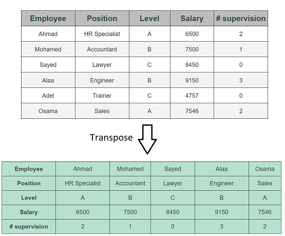

[figure not shown]

```python
v = np.array([1,2,3])
print (v)
```

```
[1 2 3]
```

```python
v2 = v.T
print (v2)
```

```
[1 2 3]
```

```python
print(v.shape)
print(v2.shape)
```

```
(3,)
(3,)
```

```python
m = np.array([[1,2,3]])
print (m)
```

```
[[1 2 3]]
```

```python
m2 = m.T
print (m2)
```

```
[[1]
 [2]
 [3]]
```

```python
print(m.shape)
print(m2.shape)
```

```
(1, 3)
(3, 1)
```

```python
m = np.array ([[11, 12, 13], [21, 22, 23], [31, 32, 33], [5, 6, 7]])
print (m)
```

```
[[11 12 13]
 [21 22 23]
 [31 32 33]
 [ 5  6  7]]
```

```python
m2 = m.T
print (m2)
```

```
[[11 21 31  5]
 [12 22 32  6]
 [13 23 33  7]]
```

```python
print(m.shape)
print(m2.shape)
```

```
(4, 3)
(3, 4)
```

```python
np.transpose(m)  # m.T
```

```
array([[11, 21, 31,  5],
       [12, 22, 32,  6],
       [13, 23, 33,  7]])
```

# Determinant

[figure not shown]

Image Credit : [sharetechnote](https://www.sharetechnote.com/html/Handbook_EngMath_Matrix_Determinent.html)

> - Only for Square Matrix
- Only for Invertible Matrix

```python
A = np.array ([[4,3],[3,2]])
A
```

```
array([[4, 3],
       [3, 2]])
```

```python
np.linalg.det(A)        # (4*2 - 3*3)
```

```
np.float64(-1.0)
```

**Useful Source : [Mathisfun: Determinant](https://www.mathsisfun.com/algebra/matrix-determinant.html)**

# Inverse

[figure not shown]

Image Credit : [The Calculator](https://www.thecalculator.co/math/Inverse-Matrix-Calculator-724.html)

```python
A = np.array ([[4,3],[3,2]])
A
```

```
array([[4, 3],
       [3, 2]])
```

```python
B = np.linalg.inv(A)
B
```

```
array([[-2.,  3.],
       [ 3., -4.]])
```

# Dot Product

[figure not shown]

```python
np.dot(A,B)  # A.dot(B)
```

```
array([[1., 0.],
       [0., 1.]])
```

```python
np.dot(B,A)
```

```
array([[1., 0.],
       [0., 1.]])
```

**Useful Source : [Mathisfun: Dot Product](https://www.mathsisfun.com/algebra/matrix-multiplying.html)**

```python
A = np.array([[1,2,3], [4, 5, 6]])
B = np.array([[7,8], [9,10], [11,12]])
```

```python
np.dot(A,B)
```

```
array([[ 58,  64],
       [139, 154]])
```

```python
np.dot(B,A)
```

```
array([[ 39,  54,  69],
       [ 49,  68,  87],
       [ 59,  82, 105]])
```

📌 **Insight:** Watch shapes, not just values — `.T` on a 1-D vector changes nothing (shape `(3,)` stays `(3,)`), `det`/`inv` need square matrices, and `dot` needs inner dimensions to match `(2, 3) @ (3, 2)` works; swapping the order gives a different-shaped result).

# 📊 Chapter 7: Aggregation & Axis

### 🎯 Goal:

Summarize arrays with **aggregations** (`sum`/`mean`/`min`/`max`/`std`) and control **which direction** they run with `axis` — the direct prep for central tendency and spread in Descriptive Statistics.

## 🧾 Sample Data (synthetic weekly sales)

- *What:* A 3×3 array — 3 branches (rows) × 3 products (columns).
- *Why:* One tiny array demonstrates every aggregation pattern.
- *When to use:* Any time you collapse detail into totals or averages.

```python
sales = np.array([[120, 200, 150],
                  [180, 160, 210],
                  [140, 190, 170]])
sales
```

```
array([[120, 200, 150],
       [180, 160, 210],
       [140, 190, 170]])
```

## ➕ Whole-Array Totals & Average

```python
np.sum(sales)   # grand total
```

```
np.int64(1520)
```

```python
np.mean(sales)  # overall average (central tendency)
```

```
np.float64(168.88888888888889)
```

## 📏 Spread: min / max / std

```python
np.min(sales), np.max(sales)  # range ends
```

```
(np.int64(120), np.int64(210))
```

```python
np.std(sales)   # spread of the data (standard deviation)
```

```
np.float64(27.666443551086072)
```

## 🧭 Axis: which direction?

- *What:* `axis=0` collapses **rows** (result per column); `axis=1` collapses **columns** (result per row).
- *Why:* Answers "per product" vs "per branch" questions.
- *When to use:* Every grouped summary — the same idea as pandas `groupby`.

```python
np.sum(sales, axis=0)  # per product (column totals)
```

```
array([440, 550, 530])
```

```python
np.sum(sales, axis=1)  # per branch (row totals)
```

```
array([470, 550, 500])
```

```python
np.mean(sales, axis=0)  # average sales per product
```

```
array([146.66666667, 183.33333333, 176.66666667])
```

```python
np.max(sales, axis=1)   # best-selling product per branch
```

```
array([200, 210, 190])
```

📌 **Insight:** `axis=` names the dimension that **disappears** — `axis=0` on a `(3, 3)` array returns shape `(3,)`, one value per column.

# 🔀 Chapter 8: Reshape & Broadcasting

### 🎯 Goal:

Change array **shapes without changing data** (`reshape`) and predict how **mismatched shapes combine** (broadcasting rules) — the #1 source of ML shape errors.

## 📐 Reshape

- *What:* `reshape` reorganizes the same data into a new shape.
- *Why:* Turn flat data into rows/columns (or back) for models and plots.
- *When to use:* Preparing feature matrices; `-1` means "infer this dimension".

```python
flat = np.arange(1, 7)
flat
```

```
array([1, 2, 3, 4, 5, 6])
```

```python
flat.reshape(2, 3)   # 2 rows x 3 cols
```

```
array([[1, 2, 3],
       [4, 5, 6]])
```

```python
flat.reshape(-1)     # flatten back (infer the size)
```

```
array([1, 2, 3, 4, 5, 6])
```

```python
flat.reshape(6, 1)   # column vector — compare with Chapter 2
```

```
array([[1],
       [2],
       [3],
       [4],
       [5],
       [6]])
```

## 📡 Broadcasting Rules

- *What:* NumPy stretches dimensions of size 1 (or missing ones) to match the other operand.
- *Why:* Adds per-row / per-column adjustments without loops.
- *When to use:* Normalizing columns, adding biases, scaling features.

```python
col = np.array([[10], [20], [30]])   # shape (3, 1)
row = np.array([1, 2, 3])            # shape (3,)
col + row  # (3,1) + (3,) -> (3,3)
```

```
array([[11, 12, 13],
       [21, 22, 23],
       [31, 32, 33]])
```

```python
sales + np.array([10, 0, -5])  # per-product adjustment across all branches
```

```
array([[130, 200, 145],
       [190, 160, 205],
       [150, 190, 165]])
```

📌 **Insight:** If shapes mismatch unexpectedly, print `.shape` on both sides first — broadcasting aligns from the **right**, and a missing dimension is treated as size 1.

## 📌 Final Summary

In this tutorial, you built the NumPy foundation for everything ahead:

- ⚙️ Setup: `import numpy as np`; arrays compute element by element, lists do not
- 🧱 Building blocks: scalar / vector / matrix — read any array via `dtype`, `shape`, `ndim`
- 🏗️ Factories: `zeros / ones / full / empty`, `eye`, `arange`, `linspace`, `random` (+ `seed`)
- 🔍 Selection: positional slicing, boolean masks, `where`, set ops, fancy indexing
- ➕ Element-wise math: `+ - * /`, scalar broadcasting, `sqrt / exp / log`
- ✖️ Linear algebra: transpose (1-D gotcha!), `det`, `inv`, `dot` shape rules
- 📊 Aggregation: `sum / mean / min / max / std` with `axis=0` (per column) vs `axis=1` (per row)
- 🔀 Shapes: `reshape` (with `-1`) and right-aligned broadcasting

### 🧰 Cheat Sheet

| Task | Code |
| --- | --- |
| Inspect | `a.shape`, `a.dtype`, `a.ndim` |
| Create | `np.zeros((3, 4))`, `np.ones_like(A)`, `np.arange(3, 10, 2)`, `np.linspace(0, 1, 5)` |
| Random | `np.random.seed(0)`, `np.random.randn(2, 4)`, `np.random.randint(5, 20, size=(2, 4))` |
| Select | `a[0:2]`, `a[::-1]`, `b[:2, 1]`, `a[a > 2]`, `C[[1, 2]]` |
| Math | `A + B`, `A * 2`, `np.sqrt(A)`, `np.log(A)` |
| LinAlg | `m.T`, `np.linalg.det(A)`, `np.linalg.inv(A)`, `np.dot(A, B)` |
| Aggregate | `np.sum(x, axis=0)`, `np.mean(x, axis=1)`, `np.std(x)` |
| Reshape | `x.reshape(2, 3)`, `x.reshape(-1)`, `x.reshape(3, 1)` |

**Next step:** open `02- Pandas Tutorial` — boolean masks and `axis` logic reappear as DataFrame filtering and `groupby`.